# Google Data Analytics capstone project: Fitabase wellness data analysis

Woramon P.

2022-07-29

# Introduction

This project analyzes wellness data from fitness trackers to find wellness trends and how they can be used to influence business marketing strategy.

The analyst received the following questions from the stakeholders at Bellabeat, a high-tech wellness product company:

- What are some trends in smart device usage?
- How could these trends apply to Bellabeat customers?
- How could these trends help influence Bellabeat marketing strategy?

The analyst asked the following questions regarding wellness trends:

- Are users more active on a particular day of the week?
- Is there a relationship between sedentary time and sleep duration each day?

# Data source

The stakeholder provided the analyst with the following data set: FitBit Fitness Tracker Data (CC0: Public Domain, dataset made available through Mobius), available [here](https://www.kaggle.com/datasets/arashnic/fitbit).

The analyst first processed tables in the data set using SQL in BigQuery, the result of which is “BigQuery_result.csv” which will be used in the following analysis. Refer to a separate file for the BigQuery code.

# Getting to know the data

To perform analysis, install and load the following packages.

```r
library(tidyverse)
library(readr)
```

Import data and view its structure. It has 23 columns such as:

- user_id: Representing each of the 33 users
- date_: Ranging from 2016-04-12 to 2016-05-12.
- time_: Time of day
- day: From 1 to 7, representing Sunday to Saturday
- daily_minutes_asleep: Amount of sleep per day
- daily_minutes_1sedentary: Amount of sedentary time per day
- daily_minutes_2lightlyactive: Amount of lightly active time per day
- daily_minutes_3fairlyactive: Amount of fairly time per day
- daily_minutes_4veryactive: Amount of very time per day
- and so on

```r
df0 <- read_csv("BigQuery_result.csv")
colnames(df0)
```

```
##  [1] "user_id"                          "date_"
##  [3] "time_"                            "day"
##  [5] "minute_METs"                      "hourly_steps"
##  [7] "hourly_intensity_total"           "hourly_intensity_avg"
##  [9] "hourly_calories"                  "daily_minutes_asleep"
## [11] "daily_minutes_in_bed"             "daily_calories"
## [13] "daily_steps"                      "daily_distance_total"
## [15] "daily_distance_tracker"           "daily_distance_4veryactive"
## [17] "daily_distance_3moderatelyactive" "daily_distance_2lightlyactive"
## [19] "daily_distance_1sedentary"        "daily_minutes_4veryactive"
## [21] "daily_minutes_3fairlyactive"      "daily_minutes_2lightlyactive"
## [23] "daily_minutes_1sedentary"
```

Currently, data in the user_id column is in a numeric data type. The analyst converts them into characters and shorten them to just the first 4 numbers for easy reference.

```r
chr <- as.character(df0$user_id)
df0$user_id <- substr(chr, 1, 4)
unique(df0$user_id)
```

```
##  [1] "1503" "1624" "1644" "1844" "1927" "2022" "2026" "2320" "2347" "2873"
## [11] "3372" "3977" "4020" "4057" "4319" "4388" "4445" "4558" "4702" "5553"
## [21] "5577" "6117" "6290" "6775" "6962" "7007" "7086" "8053" "8253" "8378"
## [31] "8583" "8792" "8877"
```

The analyst takes a look at data distribution. First, she checks how many rows of data there are for each user and finds that some users provide fewer data than others.

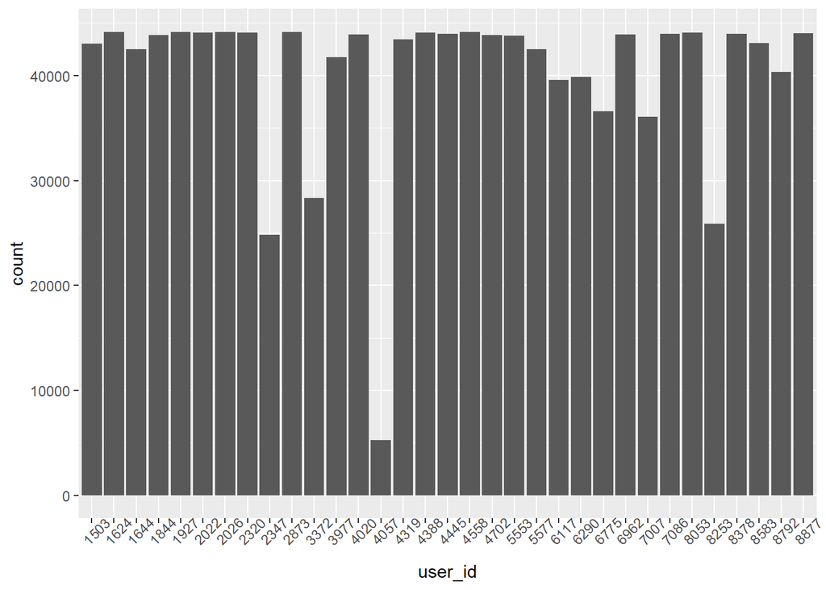

```r
ggplot(data=df0, aes(x=user_id)) + geom_bar() + theme(axis.text.x = element_text(angle = 45))
```

She checks how many rows of data there are from different dates and finds that there are more data from early days of data collection.

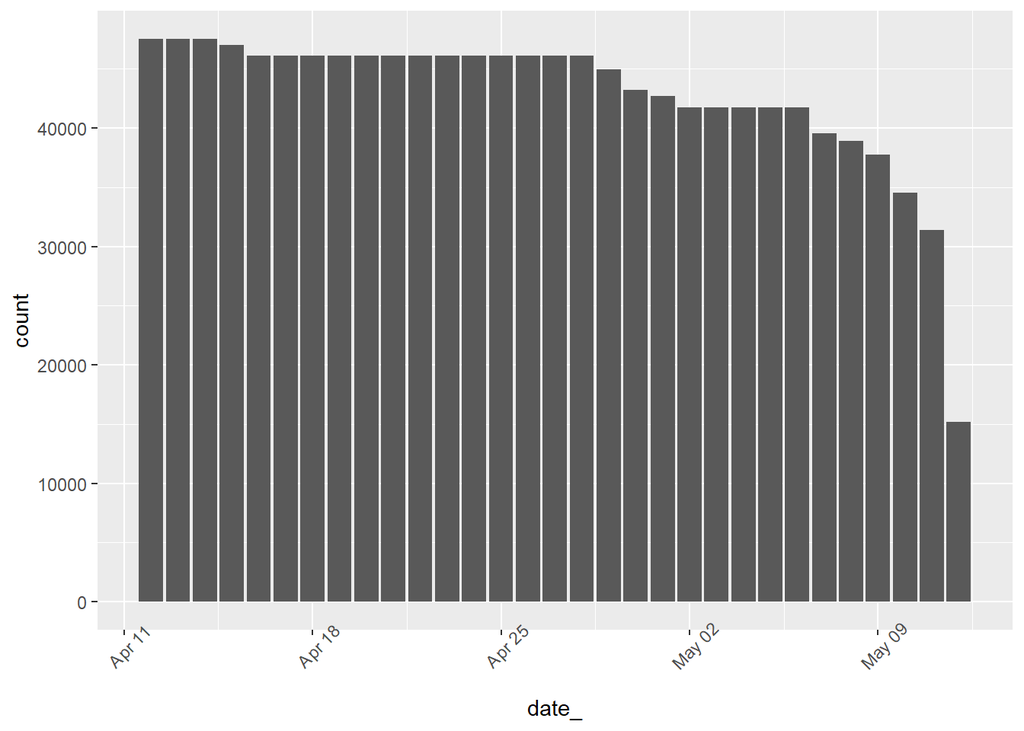

```r
ggplot(data=df0, aes(x=date_)) + geom_bar() +
  theme(axis.text.x = element_text(angle = 45))
```

She checks how many rows of data there are from different times of the day and finds that there are slightly more data from early in the day.

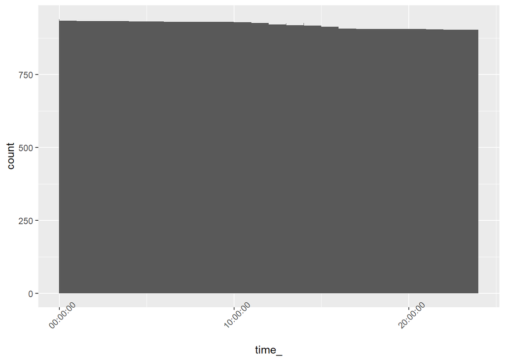

```r
ggplot(data=df0, aes(x=time_)) + geom_bar() +
  theme(axis.text.x = element_text(angle = 45)) +
  guides(fill=guide_legend(title="date"))
```

# Analysis

## Question 1: Are users more active on a particular day of the week?

To answer this question, the analyst creates a new data frame containing the days of the week and how much time users spent on each of the activeness categories (sedentary, lightly active, fairly active, very active).

```r
df1 <- select(df0, day, daily_minutes_1sedentary, daily_minutes_2lightlyactive, daily_minutes_3fairlyactive, daily_minutes_4veryactive)
```

She drops the rows with no data for activeness.

```r
df1 <- df1[!(is.na(df0$daily_minutes_4veryactive)), ]
# The `daily_minutes_4veryactive` variable is used here, but any of the three related variables (daily_minutes_1sedentary, daily_minutes_2lightlyactive, daily_minutes_3fairlyactive) can also be used to drop the rows.
```

Let’s have a look at the result.

```r
head(df1)
```

```
## # A tibble: 6 × 5
##     day daily_minutes_1sedentary daily_minutes_2lightlyactive daily_mi…¹ daily…²
##   <dbl>                    <dbl>                        <dbl>      <dbl>   <dbl>
## 1     3                      728                          328         13      25
## 2     4                      776                          217         19      21
## 3     5                     1218                          181         11      30
## 4     6                      726                          209         34      29
## 5     7                      773                          221         10      36
## 6     1                      539                          164         20      38
## # … with abbreviated variable names ¹daily_minutes_3fairlyactive,
## #   ²daily_minutes_4veryactive
```

The analyst wants to create a [percent stacked bar chart](https://r-graph-gallery.com/48-grouped-barplot-with-ggplot2.html). To prepare data for chart drawing, she reshapes the data from wide to long format.

```r
df2 <- pivot_longer(df1, !day, names_to = "active_level", values_to = "minutes")
```

Let’s look at the data after being reshaped.

```r
head(df2)
```

```
## # A tibble: 6 × 3
##     day active_level                 minutes
##   <dbl> <chr>                          <dbl>
## 1     3 daily_minutes_1sedentary         728
## 2     3 daily_minutes_2lightlyactive     328
## 3     3 daily_minutes_3fairlyactive       13
## 4     3 daily_minutes_4veryactive         25
## 5     4 daily_minutes_1sedentary         776
## 6     4 daily_minutes_2lightlyactive     217
```

She draws a percent stacked bar chart to see the percentage of time users spent on different activeness levels.

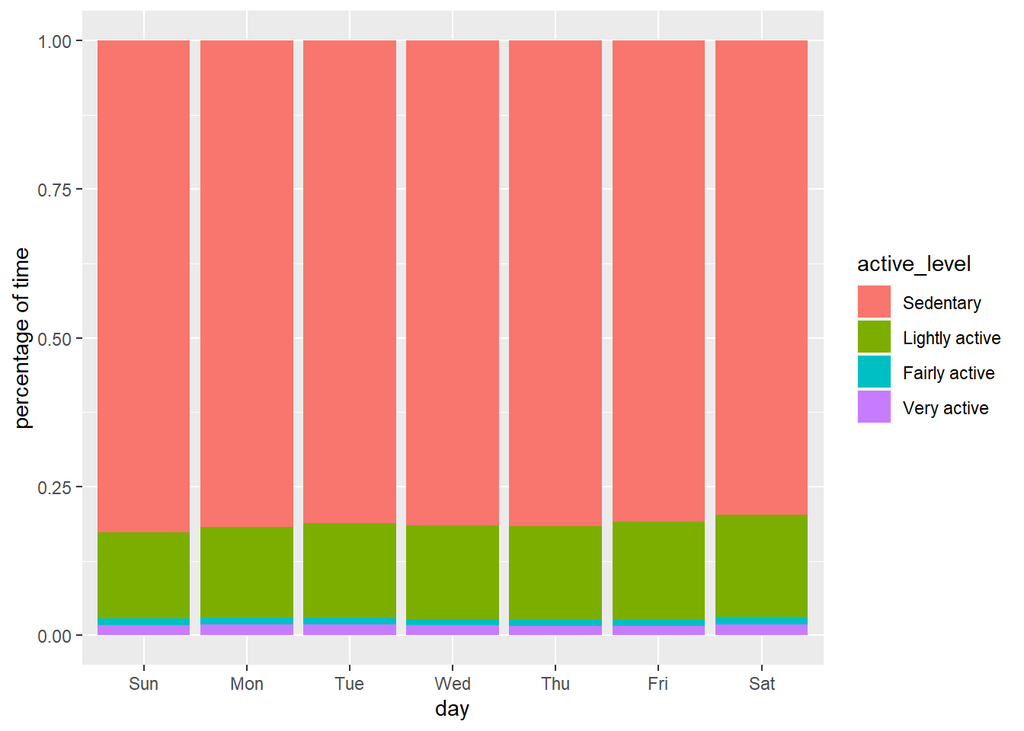

```r
ggplot(df2, aes(x = factor(day), y = minutes, fill = active_level)) +
  geom_bar(position = "fill", stat = "identity") +
  scale_x_discrete(labels=c("1" = "Sun", "2" = "Mon", "3" = "Tue", "4" = "Wed", "5" = "Thu", "6" = "Fri", "7" = "Sat")) +
  labs(x="day", y="percentage of time") +
  scale_fill_discrete(labels=c("Sedentary", "Lightly active", "Fairly active", "Very active"))
```

Since sedentary activities takes up a large proportion of the users’ time in a day, the analyst zooms in to focus on other activeness levels.

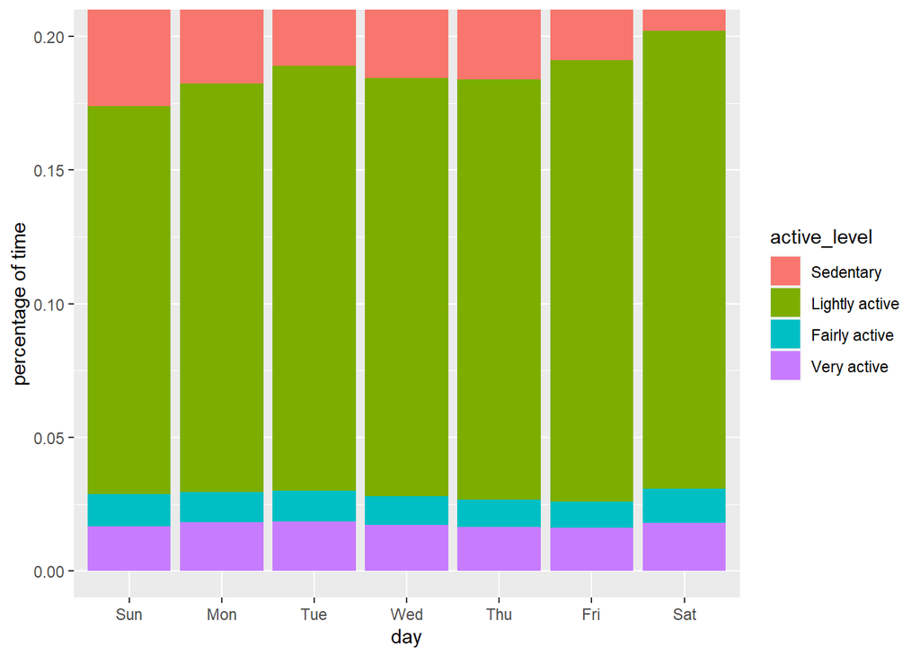

```r
ggplot(df2, aes(x = factor(day), y = minutes, fill = active_level)) +
  geom_bar(position = "fill", stat = "identity") +
  scale_x_discrete(labels=c("1" = "Sun", "2" = "Mon", "3" = "Tue", "4" = "Wed", "5" = "Thu", "6" = "Fri", "7" = "Sat")) +
  labs(x="day", y="percentage of time") +
  scale_fill_discrete(labels=c("Sedentary", "Lightly active", "Fairly active", "Very active")) +
  coord_cartesian(ylim = c(0, 0.20))
```

**Finding**: The users seemed to be most active on Saturdays and least active on Sundays.

## Question 2: Is there a relationship between sedentary time and sleep duration?

To answer this question, the analyst creates a new data frame containing daily sedentary time and sleep duration.

```r
df3 <- select(df0, daily_minutes_1sedentary, daily_minutes_asleep)
```

She drops the rows with no data for sleep.

```r
df3 <- df3[!(is.na(df0$daily_minutes_asleep)), ]
```

Let’s have a look at the result.

```r
head(df3)
```

```
## # A tibble: 6 × 2
##   daily_minutes_1sedentary daily_minutes_asleep
##                      <dbl>                <dbl>
## 1                      728                  327
## 2                      776                  384
## 3                      726                  412
## 4                      773                  340
## 5                      539                  700
## 6                      775                  304
```

She draws a [scatterplot](https://r-graph-gallery.com/272-basic-scatterplot-with-ggplot2.html) to see the relationship.

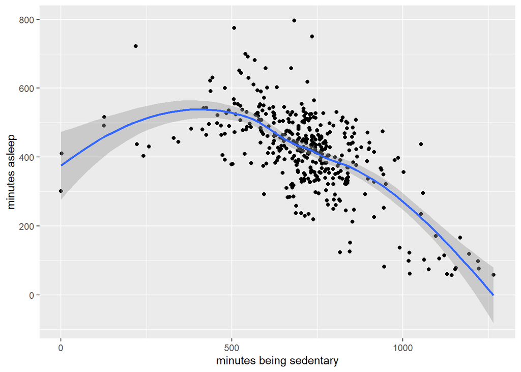

```r
ggplot(data=df3, aes(x=daily_minutes_1sedentary, y=daily_minutes_asleep)) +
  geom_point() + geom_smooth() +
  labs(x="minutes being sedentary", y="minutes asleep")
```

**Finding**: The trend suggests a negative correlation between the amount of sedentary time and the amount of sleep.

The analyst is aware that correlation does not imply causation. The following explanations are possible and shall be further investigated:

- When people are more sedentary during the day, they have shorter sleep at night. In other words, being active may help people sleep longer at night.
- When people have shorter sleep at night, they become less active during the day, potentially due to tiredness.

# Findings and suggestions

The analyst finds two trends from the wellness data.

- The users seemed to be most active on Saturdays and least active on Sundays.
- There is a negative correlation between the amount of sedentary time and the amount of sleep.

Before providing suggestions based on the finding, it is worth reminding about limitation of the data:

- These data were collected in 2016, six years before the time of analysis, and users’ behavior may have changed since then.
- The data span over only one month in April-May. User’s behavior may be different in other seasons.
- The data come from 33 users, which is considered a small sample size.

The stakeholder asked: How could these trends apply to Bellabeat customers? How could these trends help influence Bellabeat marketing strategy?

Assuming that these data are representative of Bellabeat customers and users of high-tech wellness products in general, the analyst’s suggestions include:

- Bellabeat **creates an advertising campaign and a social media hashtag such as #SportySunday to encourage people to be more active on Sundays.**
- Bellabeat conducts more research on the relationship between sedentary activities and sleep. If it is found that sedentary activities lead to poorer sleep, the company can **market on the its products’ functionality to remind users to get active when they are sedentary for a certain period of time.**